# individual1

The Dataset:

```r
HAPPY <- readRDS("HAPPY.rds")
head(HAPPY)
```

```
##           HAPPY YEAR AGE    SEX       MARITAL         DEGREE       FINRELA
## 1 NOT TOO HAPPY 1972  23 FEMALE NEVER MARRIED       BACHELOR       AVERAGE
## 2 NOT TOO HAPPY 1972  70   MALE       MARRIED LT HIGH SCHOOL ABOVE AVERAGE
## 3  PRETTY HAPPY 1972  48 FEMALE       MARRIED    HIGH SCHOOL       AVERAGE
## 4 NOT TOO HAPPY 1972  27 FEMALE       MARRIED       BACHELOR       AVERAGE
## 5  PRETTY HAPPY 1972  61 FEMALE       MARRIED    HIGH SCHOOL ABOVE AVERAGE
## 6  PRETTY HAPPY 1972  26   MALE NEVER MARRIED    HIGH SCHOOL ABOVE AVERAGE
##      HEALTH WTSSALL          PARTYID POLVIEWS
## 1      GOOD  0.4446     IND,NEAR DEM      IAP
## 2      FAIR  0.8893 NOT STR DEMOCRAT      IAP
## 3 EXCELLENT  0.8893      INDEPENDENT      IAP
## 4      GOOD  0.8893 NOT STR DEMOCRAT      IAP
## 5      GOOD  0.8893  STRONG DEMOCRAT      IAP
## 6      GOOD  0.4446     IND,NEAR DEM      IAP
```

```r
library(dplyr)
```

```r
library(ggplot2)
```

Cleaning the Data: 1. Data cleaning: the values “IAP”, “DK” and “NA” all encode missing values. Replace all of these instances by the value NA.

```r
HAPPY[HAPPY == 'IAP'] <- NA
HAPPY[HAPPY == 'NA'] <- NA
HAPPY[HAPPY == 'DK'] <- NA
```

2. Check the type of the variable and cast into the right type (factor variable for categorical variables). For age, change “89 OR OLDER” to 89 and assume the variable should be numeric.

```r
HAPPY <- HAPPY %>% mutate_if(is.character, as.factor) %>% mutate(AGE = recode(AGE, "89 OR OLDER" = "89")) %>% mutate(AGE = as.numeric(levels(AGE)[AGE]))
```

3. Bring all levels of factors into a sensible order. For marital you could e.g. order the levels according to average age.

```r
HAPPY <- HAPPY %>% mutate(HAPPY = factor(HAPPY, levels = c('NOT TOO HAPPY', 'PRETTY HAPPY', 'VERY HAPPY')))
```

Exploration: 1. Investigate the distributions of 2 different variables.

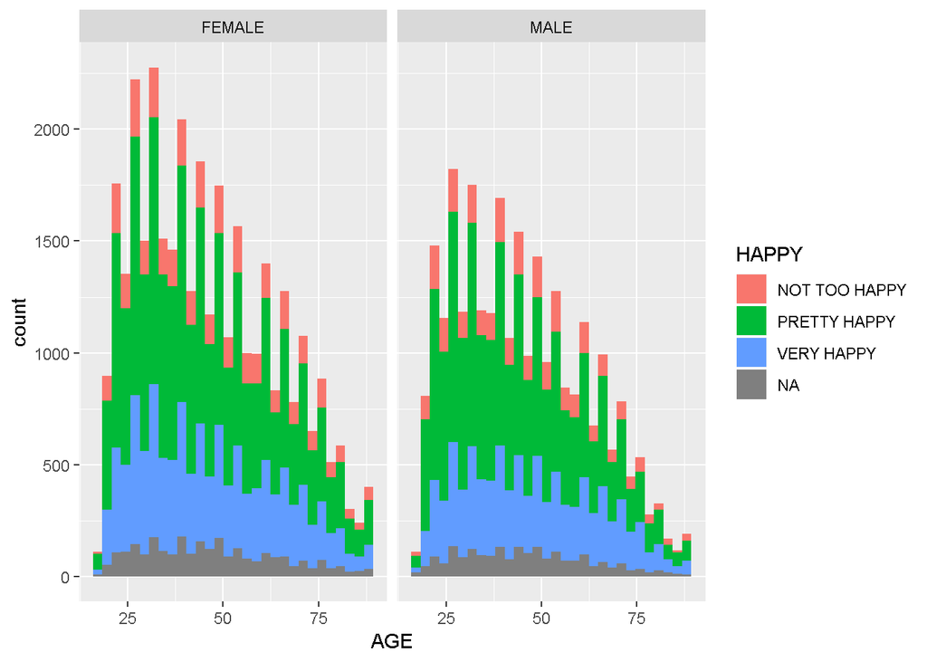

```r
ggplot(HAPPY, aes(x = AGE, fill = HAPPY)) + geom_histogram() + facet_grid((~SEX))
```

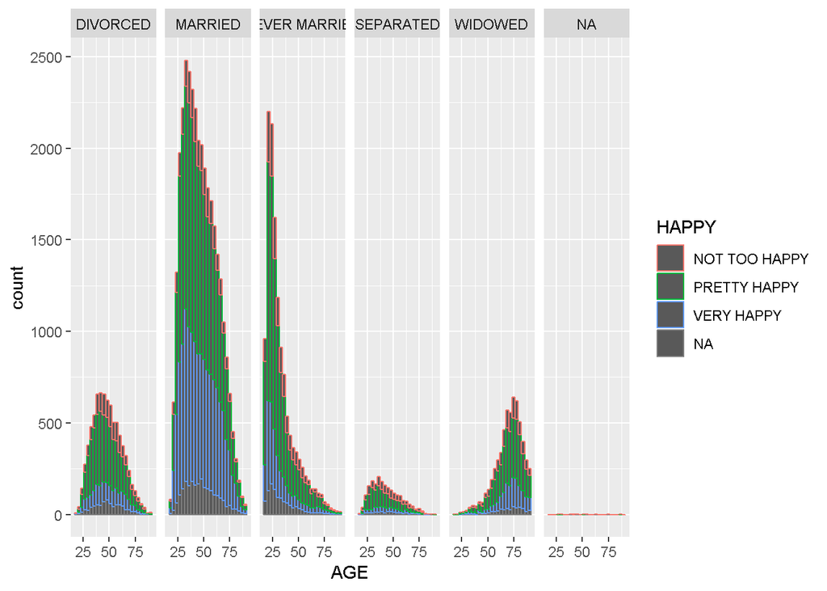

```r
ggplot(HAPPY, aes(x= AGE, color = HAPPY)) + geom_histogram(binwidth = 3) + facet_grid(~MARITAL)
```

For the first set of histograms, it shows that on average, no matter your age or sex, the most popular happiness level is pretty happy. Both distributions are skewed right. In the second set of histograms, it shows that on average, no matter your marital status, people are pretty happy. One significant thing that stands out in this set is that all the histograms are skewed right except for the Widowed status, where it is skewed left. This is because older people are more likely to become widowed than younger people.

2. Investigate the relationship between happiness and three other variables in the data.

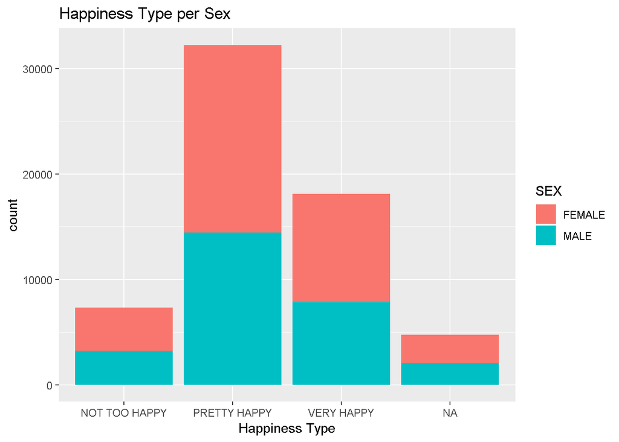

```r
ggplot(HAPPY, aes(x = HAPPY, fill = SEX)) + geom_bar() + labs(x = 'Happiness Type', title = 'Happiness Type per Sex')
```

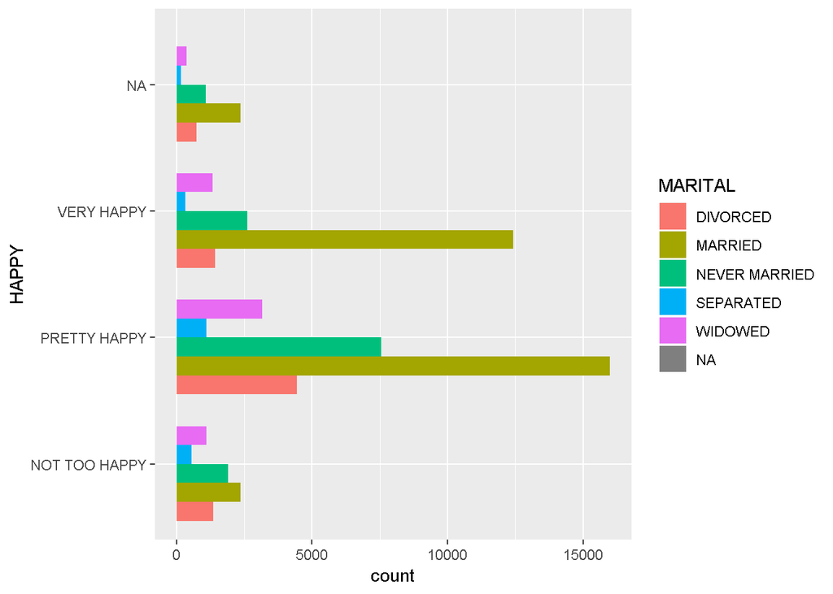

```r
ggplot(HAPPY, aes(x = HAPPY, fill = MARITAL)) + geom_bar(position = position_dodge()) + coord_flip()
```

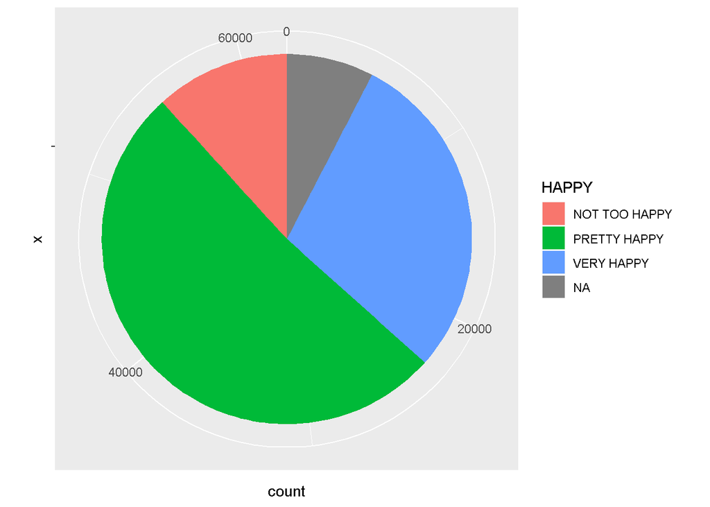

```r
ggplot(HAPPY, aes(x = '', fill = HAPPY)) + geom_bar() + coord_polar(theta = 'y')
```

3. What do you learn from the data set? Write one or two paragraphs to describe.